# Reproducibility of GIScience MSc Theses - Self-assessment experiment

Carlos Granell

Universitat Jaume I of Castellón, Spain

15/04/2020 (updated 05 septiembre, 2020)

Abstract

This document analyses the responses to a pre-questionnaire and post-questionnaire in the framework of an experiment on the [self-assesment of reproducibility level of master’s thesis in GIScience](https://osf.io/j97zp/) carried out during the academic year 2019/20 with master’s students enrolled in two GIS-related master’s programmes: [Erasmus Mundus MSc in Geospatial Technologies](https://mastergeotech.info/) and [MSc Geomatics](https://www.tudelft.nl/en/education/programmes/masters/geomatics/msc-geomatics/). This initial experiment attempts to explore teaching strategies to increase the exposure to and understanding of Reproducible Research by master-level students in the area of GIScience.

# 1 Preliminaries

## 1.1 Software dependencies

This document does not install the required R packages by default. You can run the script `install.R` to install all required dependencies on a new R installation, or use `install.packages(..)` to install missing R packages.

## 1.2 Required libraries

```r
library("tidyverse")
library("forcats")
library("kableExtra")
library("here")
library("googlesheets4")
library("likert")
# library("bookdown")
```

## 1.3 Reproduce paper

To create the PDF of the computational notebook you can run the following commands in a new R session. If you have problems rendering the PDF you can execute each chunk independently in [RStudio](https://rstudio.com/products/rstudio/).

```r
require("knitr")
require("rmarkdown")
rmarkdown::render("self-assessment-experiment.Rmd", output_format = "pdf_document")
```

# 2 Data & methods

## 2.1 Participants

Eligible participants were initially all students enrolled in the Master Thesis Project in the academic year 2019/2020 from two GIS-related master programmes:[Erasmus Mundus MSc in Geospatial Technologies](https://mastergeotech.info/) and [MSc Geomatics](https://www.tudelft.nl/en/education/programmes/masters/geomatics/msc-geomatics/). The former is offered by three universities (UJI, NOVA IMS Lisboa and Münster), the latter by TU Delft. As participation was voluntary, the experiment was not counted towards the final grade of the master’s thesis.

Students who also answered the questionnaires but were not enrolled in the master programmes above (e.g., PhD students who participated in a doctoral course at UJI) were removed from the analysis. Fields that refer to personal information (email, thesis handlers, url to pdf files) were also removed and therefore not used in the analysis.

## 2.2 Methodological steps

A brief summary of the steps follows are described below. Additional notes are also [available](https://docs.google.com/document/d/1Ev5Q2fbzrv8PQxMC9nDBUYy73AqrvZOaT3uRjAkvWIU/edit?usp=sharing).

- Step 1. Participants answered the [first questionnaire](https://forms.gle/BTmPc5ExhEJNkUtFA) (per-test assessment) at the start of the semester (or master thesis project/course).
- Step 2. In the [OSF web site](https://osf.io/j97zp/), participants were provided with an [introductory 5-minute video lecture](https://osf.io/pnw2q/) to the experiment and [20-minute video lecture to the topic of reproducibility](https://osf.io/f756x/).
- Step 3. In the same [web site](https://osf.io/j97zp/), participants were also given 3 self-study, self-paced assignments (in PDF format) to introduce them to the methods and tools for reproducibility research. To suport them, we also setup a GitHub repo as a [discussion service](https://github.com/erasmus-mundus-geotech-master/reproducibility-self-assessment) to allow all students to discuss questions with regard to the assignments and the reproducibility self-assessment of their theses.
- Step 4. Participants were asked to self-assess the level of reproducibility of their master theses, as explained in the first video lecture. In practice, it meant to add a simple statement (last line) to the abstract indicating the level (score) of each of the five criteria (Nüst et al. 2018).
- Step 5. At the end of the semester (or master thesis project/course), participants answered a [second questionnaire](https://forms.gle/KCD5Ym4VJRmZzZqNA) (post-test assessment).

## 2.4 Training materials

Training materials developed for the experiment are publicly available in the OSF project [“Reproducibility of GIScience MSc Theses - Self-assessment experiment” on the Open Science Framework](https://osf.io/j97zp/).

- [Introduction lecture to self-assessment reproducibility experiment](https://osf.io/pnw2q/)
- [Introduction lecture to reproducibility](https://osf.io/f756x/)
- [First self-study assignment](https://osf.io/b3myq/)
- [Second self-study assignment](https://osf.io/8p7sd/)
- [Third self-study assignment](https://osf.io/6f5pm/)

## 2.5 Reproducibility self-assessment data

The master’s theses of the students of the *Erasmus Mundus MSc in Geospatial Technologies* are openly available in an [institutional repository](https://run.unl.pt/handle/10362/2259/browse?type=dateissued&sort_by=3&order=ASC&rpp=30&etal=-1&year=2020&month=-1&starts_with=)

# 3 Analysis

The following plots and tables are based on the file pretest_filtered.csv in the folder `data`. Only students from *MSc in Geospatial Technologies (UJI, NOVA IMS, IFGI-WWU)* and *MSc Geomatics (TU Delft)* are analysed.

## 3.1 Questionnaire #1 (pre-test)

### 3.1.1 MSc in Geospatial Technologies (UJI, NOVA IMS, IFGI-WWU)

- 25 students of the EM MSc in Geospatial Technologies *did* eventually deliver the master thesis project.
- 48% (12/25) of students answered the first questionnaire. All but one added the self-assessment statement to the thesis manuscript.
- 52% (13/25) of students added a self-assessment statement to the master thesis. Two of them *did not* answered the questionnaire #1, so they are not included in the analysis.

#### 3.1.1.1 Section 1: Previous knowledge/experience on reproducible research

2 (out of 12) students answered that they have been previously trained on reproducible research practices.

**Imagine that you are going to explain the following terms to somebody else. How well do you KNOW them?**

Percentage of answers in the disagree (low), agree (high) or neutral categories. Mean response with standard deviation using numeric values 1 to 5 for ‘Strongly disagree’ to ‘Strongly agree’. Terms are ordered by ‘high’ category.

| School of thought | Term | low (%) | neutral (%) | high (%) | mean | sd |
| --- | --- | --- | --- | --- | --- | --- |
| democratic | Open source | 8.33 | 0.00 | 91.67 | 4.58 | 0.90 |
| democratic | Open data | 16.67 | 0.00 | 83.33 | 4.25 | 1.14 |
| democratic | Open access | 16.67 | 8.33 | 75.00 | 4.00 | 1.13 |
| democratic | License | 0.00 | 33.33 | 66.67 | 4.17 | 0.94 |
| infrastructure | Data repositories | 33.33 | 0.00 | 66.67 | 3.50 | 1.57 |
| democratic | Intellectual property rights | 8.33 | 33.33 | 58.33 | 3.67 | 0.89 |
| democratic | Data/code versioning | 16.67 | 25.00 | 58.33 | 3.58 | 1.00 |
| pragmatic | Execution environments | 33.33 | 16.67 | 50.00 | 3.00 | 1.21 |
| infrastructure | Code repositories | 33.33 | 16.67 | 50.00 | 3.42 | 1.44 |
| public | Citizen science | 25.00 | 33.33 | 41.67 | 2.92 | 1.24 |
| pragmatic | Digital notebooks | 33.33 | 25.00 | 41.67 | 3.17 | 1.27 |
| pragmatic | Reproducible packages | 50.00 | 8.33 | 41.67 | 2.83 | 1.34 |
| infrastructure | Collaborative coding repositories | 41.67 | 25.00 | 33.33 | 2.92 | 1.38 |
| public | Science dissemination | 33.33 | 33.33 | 33.33 | 2.75 | 1.22 |
| pragmatic | Analytical workflows | 58.33 | 16.67 | 25.00 | 2.42 | 1.16 |
| infrastructure | Containers platforms | 41.67 | 33.33 | 25.00 | 2.67 | 1.30 |
| public | Science blogging | 25.00 | 50.00 | 25.00 | 2.92 | 1.16 |
| pragmatic | Computational essays | 41.67 | 41.67 | 16.67 | 2.58 | 1.24 |

Table above is the raw data to create the likert-scale plot in next Figure. Students had previous knowledge (reddish answers >= 50%) for the 9 top terms, which are Open source, Open data, Open access, License, Data repositories, Intellectual property rights, Data/code versioning, Execution environments, Code repositories. The next term, Citizen science, is to some extent knowledgeable, as 1/3 opted for the neutral response The rest of terms, Digital notebooks, Reproducible packages, Collaborative coding repositories, Science dissemination, Analytical workflows, Containers platforms, Science blogging, Computational essays, are in general poorly known and/or understood. This suggests that terms closely connected to reproducibility (mostly from the *pragmatic* School of Thought, see (Fecher and Friesike 2014)) were in general unknowledgeable (yellowish answers predominate).

[figure not shown]

Previous experience in reproducibility, main difficulties and perceived importance, using numeric values 1 to 5 for ‘No important at all’ to ‘Really important’.

Have you ever experienced DIFFICULTIES IN REUSING somebody else’s code / data?

Have you ever had to REUSE YOUR OWN past code/data?

If you answered YES in either of the last two questions, please explain which were the MAIN DIFFICULTIES you experienced. If NO, skip question

Do you know where to look for HELP and extra information to make your research reproducible?

Please rate the perceived IMPORTANCE of doing your research in a reproducible way

According to you, why is it IMPORTANT (or not) to do your research in a reproducible way?

YES

YES

Recalling the work flow of code was difficult especially when i used multiple classes and libraries. Code comments do help but only for limited code. Proper documentation was missing for my codes.

no

3

Reproducibility is good in most cases but there are some research projects that should be not so open due to confidentiality and also to protect interests of researchers. If the research result is a kind of product then openness and reproducibility will give no benifit to the researcher.

YES

YES

To get the idea of what is done in each step of the workflow.

A bit.

4

If the work is reproducible, the value is significantly higher as it can be used without much more work by others. This enables improvements of the idea and process.

YES

YES

Problem of using static code in dynamic code.

No.

5

To pursue with research works and participate in conferences.

NO

NO

No, i dont know

5

Ability to obtain similar results on research objective or questions independent on the study or even experiment

YES

YES

Most time consuming part is understanding others code if they are not properly commented. Even in my code sometimes my own comments are tough to recall later.

No

5

Re-usability is one of the key step to move forward research words. Ease to understand other words in a scientific manner will help definitely.

YES

YES

To underestand the flow an the logic of the code

No

4

A research that can not be reproducible, did not have value

YES

YES

Code was structured to a certain tool and tool was not open. Data was not available in later time.

Only internet searches.

5

Reproducibility is essential because the scientific results are affected by data structure, data content, processing method and presentation methods. There are more variables and reproducibility enhances proper understanding and control of research.

YES

NO

Not really

5

It would definitely be helpful, If I or someone else would like to replicate or continue this work in different area

YES

YES

Documentation

No

4

It is important so as to verify the scientific workflow but not always possible due to restrictions in data.

YES

YES

Lack of README

Not really

5

not reproducible, means useless, and we don’t know what’s wrong if we run it again

YES

YES

not well documented and function parameter some time confused me even if I use my past codes

NO

4

it can easy and fast the productivity

YES

YES

The data itself and the pre-processing of the data before the analysis.

Haven’t really tried, but I try to keep all well documented.

5

Because so many people is doing the same thing over and over, and for a person that is learning is better to just help to understand what you did.

The plots below refer to the questions above wih numeric/logical answers.

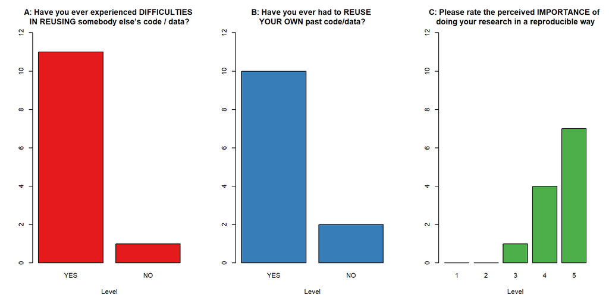

A large majority of students encountered difficulties trying to reproduce their own code or someone else’s code (A and B). The third column in the table above shows the problems the students faced. In general students gave importance to reproducibility reseaarch practices (C). As students had the chance to reproduce others’ works, reproducibility practices seem to be key for them; however, they find barriers to put these practices into practice.

#### 3.1.1.2 Section 2: Current working practices

Note that responses to ‘working practices’ were multi-choice (N=12).

|  | Practice group - Survey question |
| --- | --- |
| analysis | What tools do you plan to use to ANALYSE data? |
| visualisation | What tools do you plan to use to VISUALISE/PLOT data? |
| writing | What tools do you plan to WRITE UP your master thesis or conference/journal article? |
| workflow | What is your (expected) process of GETTING the summary data, statistical results, figures, maps and tables IN your master thesis document (or conference/journal article)? |

[figure not shown]

#### 3.1.1.3 Section 3: Previous education background / work experience /…

Previous education background and work experience, and prospects for future.

| What BACHELOR DEGREE (or equivalent) did you have when applying for the master programme? | How many years of PROFESSIONAL EXPERIENCE did you have when applying for the master programme? | In which context are you DEVELOPING your master thesis? | Please select which sentence better describes the PLAN you have after the completion of your Master thesis |
| --- | --- | --- | --- |
| Computational Physics | Over 2 years | At the university | Not sure yet |
| Bachelor of engineering | None | At the university | Not sure yet |
| Information Technology(Engineering) | Up to 2 years | At the university | Continue with doctoral studies (or another master degree) |
| BCS in Computer science | Over 2 years | At the university | Continuing in my previous job (teaching GIS in university) |
| Bachelor in Computer Science and Engineering. | Over 2 years | At the university | Find a job in academia (researcher, technician, etc) or in education-related institutions (teacher, etc) |
| Geography | None | As internship in industry | Find a job in academia (researcher, technician, etc) or in education-related institutions (teacher, etc) |
| Bachelor in Geomatics Engineering | Over 2 years | At the university | Find a job in government agencies or institutions |
| Bachelor in Geomatics Engineering | Over 2 years | At the university | Have to continue previous job (Government ) for some period |
| Urban and Regional Planning | None | At the university | Continue with doctoral studies (or another master degree) |
| Computer Science | Over 2 years | At the university | Find a job in industry (or set up own company) |
| Civil engineering | Over 2 years | At the university | Continue with doctoral studies (or another master degree) |
| Natural Renewable Resource Engeneering | Up to 2 years | At the university | Find a job in industry (or set up own company) |

### 3.1.2 Results of self-assessment reproducibility

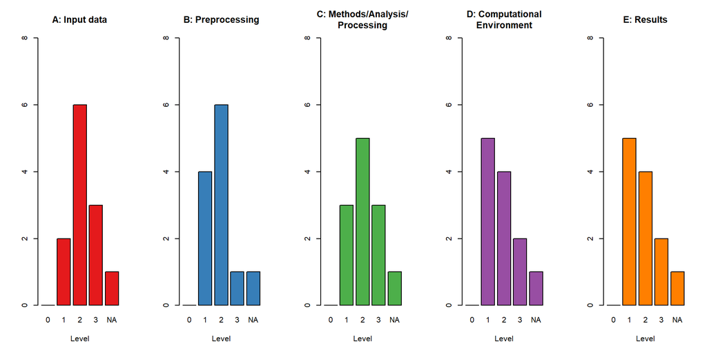

The distribution of the reproducibility levels by criteria contrasts notably with the results obtained for the evaluation of the AGILE/GIScience papers Surprisingly, all the criteria achieve level `3`, the highest (ideal) reproducibility level. `NA` level count (1 per criterion) corresponds to the student who answered the questionnaire but did not do the self-assessment. So, NA’s are not relevant for the analysis; none of the students who *did* the self-assessment assigned NA values to the criteria. Indeed, the lowest score for any criteria was `1` which sets the bar quite high. Without a reproducibility check by a third person, these self-assessment values seem to be quite inflated, well above the stadnards level we found in academic publications. This can be interpreted at least in tow ways. First, master theses were of outstading quality with regards reproducibility (*really?*). Second, or the most credible interpretation, students did not understand well the reproducibility levels and criteria and failed to do an objective self-evaluation.

## 3.2 Questionnaire #2 (post-test)

### 3.2.1 MSc in Geospatial Technologies (UJI, NOVA IMS, IFGI-WWU)

- 28% (7/25) of students answered the second questionnaire. All added the self-assessment statement to the thesis manuscript.

#### 3.2.1.1 Section 1: Previous knowledge/experience on reproducible research

**Imagine that you are going to explain the following terms to somebody else. How well do you KNOW them?**

Percentage of answers in the disagree (low), agree (high) or neutral categories. Mean response with standard deviation using numeric values 1 to 5 for ‘Strongly disagree’ to ‘Strongly agree’. Terms are ordered by ‘high’ category.

| School of thought | Term | low (%) | neutral (%) | high (%) | mean | sd |
| --- | --- | --- | --- | --- | --- | --- |
| democratic | Open access | 0.00 | 0.00 | 100.00 | 4.86 | 0.38 |
| democratic | Open data | 0.00 | 14.29 | 85.71 | 4.57 | 0.79 |
| infrastructure | Code repositories | 0.00 | 14.29 | 85.71 | 4.57 | 0.79 |
| democratic | Open source | 0.00 | 14.29 | 85.71 | 4.71 | 0.76 |
| pragmatic | Reproducible packages | 0.00 | 14.29 | 85.71 | 4.29 | 0.76 |
| infrastructure | Data repositories | 0.00 | 14.29 | 85.71 | 4.43 | 0.79 |
| pragmatic | Analytical workflows | 28.57 | 0.00 | 71.43 | 3.71 | 1.25 |
| infrastructure | Collaborative coding repositories | 28.57 | 0.00 | 71.43 | 3.71 | 1.25 |
| democratic | Intellectual property rights | 0.00 | 42.86 | 57.14 | 3.71 | 0.76 |
| pragmatic | Digital notebooks | 42.86 | 0.00 | 57.14 | 3.43 | 1.40 |
| pragmatic | Execution environments | 14.29 | 28.57 | 57.14 | 3.86 | 1.21 |
| public | Science blogging | 28.57 | 14.29 | 57.14 | 3.43 | 1.13 |
| public | Science dissemination | 28.57 | 14.29 | 57.14 | 3.14 | 1.57 |
| democratic | Data/code versioning | 0.00 | 57.14 | 42.86 | 3.71 | 0.95 |
| public | Citizen science | 42.86 | 14.29 | 42.86 | 3.00 | 1.41 |
| democratic | License | 14.29 | 57.14 | 28.57 | 3.43 | 1.13 |
| pragmatic | Computational essays | 42.86 | 28.57 | 28.57 | 3.00 | 1.53 |
| infrastructure | Containers platforms | 42.86 | 28.57 | 28.57 | 2.71 | 1.50 |

Table above is the raw data to create the likert-scale plot in next Figure.

[figure not shown]

#### 3.2.1.2 Section 2: Perceived importance of reproducibility in their future careers

Perceived importance of reproducibility in the future, using numeric values 1 to 5 for ‘No important at all’ to ‘Really important’.

| Are you going to use/adapt reproducible research practice(s) in your current and/or future research projects (master thesis, doctoral thesis, etc.)? | Are you planning to learn more about reproducible research on your own? | How important are reproducibility practices for your future professional career (academia, industry, government, etc.)? |
| --- | --- | --- |
| Not now, but I will definitively use/adapt them in the future | 4 | 4 |
| Yes, I am going to use/adapt them from now | 4 | 5 |
| Yes, I am going to use/adapt them from now | 5 | 5 |
| Not now, but I will definitively use/adapt them in the future | 5 | 4 |
| Yes, I am going to use/adapt them from now | 4 | 4 |
| Yes, I am going to use/adapt them from now | 5 | 5 |
| Not now, but maybe I will explore them in the future | 2 | 4 |

The plots below refer to the questions above wih numeric/logical answers.

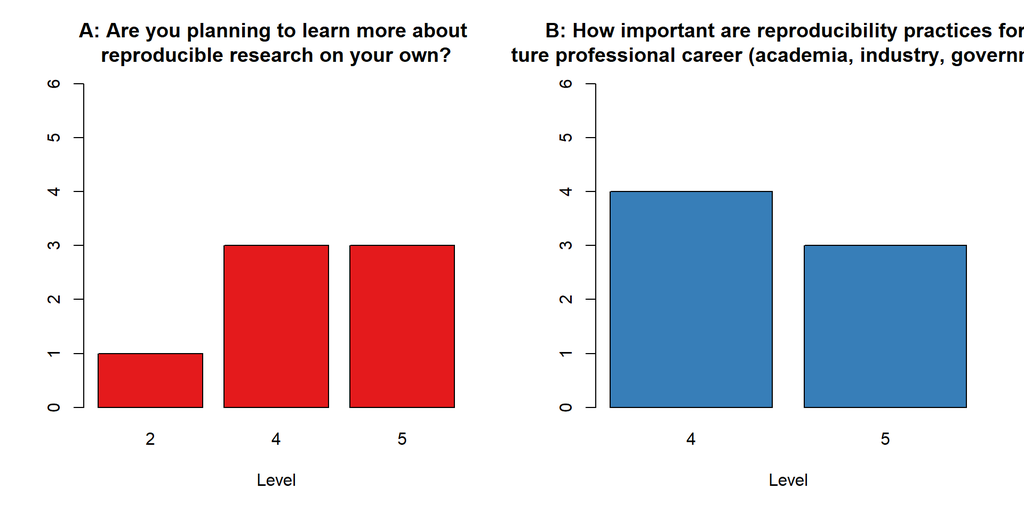

# References

Fecher, Benedikt, and Sascha Friesike. 2014. “Open Science: One Term, Five Schools of Thought.” In *Opening Science*, 17–47. Springer, Cham. https://doi.org/10.1007/978-3-319-00026-8_2.

Nüst, D, C Granell, B Hofer, M Konkol, FO Ostermann, R Sileryte, and V Cerutti. 2018. “Reproducible Research and Giscience: An Evaluation Using Agile Conference Papers.” *PeerJ* 6: e5072. https://doi.org/10.7717/peerj.5072.